# Anderson-Rose Dam Daily Flow

October 2026

## Overview

Daily flow (cfs) at Anderson-Rose Dam on the Lost River, compiled from the Tulelake Irrigation District (TID) daily report workbooks in `data-raw/anderson-rose-dam/`. The workbooks come in two layouts:

| Period | Files | Where Anderson-Rose is |
| --- | --- | --- |
| 1996 - 2011 | `Daily YYYY.xls(x)`, one workbook per calendar year | the `SPILL` tab: a single grid of days (rows) by months (columns) |
| WY 2011-12 onward | `TID Daily Report ... WY.xls(x)`, one workbook per water year (Oct - Sep) | one tab per month; the `ANDERSON-ROSE` column (called `ANDERSON-ROSE SPILL` in a couple of tabs) |

This document is the QA walkthrough for the Anderson-Rose step of the flow pipeline. It reads both layouts, repairs the date problems found in a handful of tabs, checks the result, and builds a daily series in the same shape as `flow_data` / `flow_gage`. The same logic now runs in the pipeline: the workbooks are read in `flow-data-pull.R` (using `anderson-rose-pull-helpers.R`) and cleaned and added to `flow_data` / `flow_gage` in `flow-process-data.R`. **This document does not modify any package data.** It shows everything in the workbooks, while the pipeline clips to its standardized window (through 2025-12-31) like the other flow sources.

```r
ar_dir <- here("data-raw", "anderson-rose-dam")

# Identifiers for the flow_data / flow_gage rows. flow_data/flow_gage lowercase every
# character column except gage_id. "tid-anderson-rose" follows the "<source>-<site>" pattern
# used for the other non-USGS gages (e.g. "usbr-lrd", "karuk-11523000"); the workbooks have no
# official station code to use instead.
ar_meta <- list(
  location  = "lost river",
  gage_name = "anderson-rose dam",
  gage_id   = "tid-anderson-rose",
  agency    = "tulelake irrigation district"  # from the "TID Daily Report" workbook names - confirm
)
```

## 1996 - 2011: the `SPILL` tab

Every `SPILL` tab has the same layout: the title (with the year) in `A1`, a header row starting with `DAY` followed by `JAN` … `DEC`, then 31 day rows of daily cfs. Below the grid the tab has monthly totals (`CFS`, `AF`, `AAF`) and a table of prior years, none of which are needed here. Days that don’t exist in a month (Feb 30, Apr 31, …) are present in the grid, so they are dropped by building a real date and discarding the ones that fail.

```r
month_abb <- c(JAN = 1, FEB = 2, MAR = 3, APR = 4, MAY = 5, JUN = 6,
               JUL = 7, AUG = 8, SEP = 9, OCT = 10, NOV = 11, DEC = 12)

read_spill_tab <- function(path) {
  year <- as.integer(str_extract(basename(path), "\\d{4}"))
  raw  <- read_excel(path, sheet = "SPILL", col_names = FALSE, col_types = "text",
                     .name_repair = "minimal")

  # The title carries the year too. Several newer tabs turned out to have a template copied
  # forward without updating the year, so confirm the two agree rather than assume.
  title_year <- as.integer(str_extract(raw[[1]][1], "\\d{4}"))
  if (!identical(year, title_year)) stop(basename(path), ": title year ", title_year, " != file year ", year)

  header_row <- which(str_to_upper(trimws(raw[[1]])) == "DAY")[1]
  day_rows   <- header_row + 1:31
  if (!identical(suppressWarnings(as.integer(raw[[1]][day_rows])), 1:31)) {
    stop(basename(path), ": the 31 rows under the DAY header are not days 1-31")
  }

  header     <- str_to_upper(trimws(unlist(raw[header_row, ])))
  month_cols <- which(header %in% names(month_abb))

  # The row labelled "CFS" under the grid is the sheet's own monthly total of the daily values;
  # kept so the parse can be reconciled against it below.
  cfs_row <- which(str_to_upper(trimws(raw[[1]])) == "CFS")[1]

  map_dfr(month_cols, function(col) {
    tibble(
      year = year, month = unname(month_abb[header[col]]), day = 1:31,
      value = suppressWarnings(as.numeric(raw[[col]][day_rows])),
      sheet_month_total = suppressWarnings(as.numeric(raw[[col]][cfs_row])),
      source_file = basename(path)
    )
  })
}

spill_files <- list.files(ar_dir, pattern = "^Daily \\d{4}\\.xlsx?$", full.names = TRUE)

spill_cells <- map_dfr(spill_files, read_spill_tab) |>
  mutate(date = make_date(year, month, day))   # NA where the day doesn't exist in that month

spill_daily <- spill_cells |>
  filter(!is.na(date)) |>
  transmute(date, value, source_file, source_rank = year)
```

Read 16 workbooks (1996 - 2011), 5844 real days.

### Check: do the parsed values add up to the sheet’s own monthly totals?

```r
spill_recon <- spill_cells |>
  filter(!is.na(date)) |>
  group_by(year, month) |>
  summarise(parsed_total = sum(value, na.rm = TRUE),
            sheet_total  = first(sheet_month_total), .groups = "drop") |>
  mutate(difference = parsed_total - sheet_total)

spill_recon |> filter(abs(difference) >= 0.5) |> kable(caption = "Months where the parsed total differs from the sheet's own total")
```

Months where the parsed total differs from the sheet’s own total

| year | month | parsed_total | sheet_total | difference |
| --- | --- | --- | --- | --- |
| 2002 | 2 | 3034 | 3064 | -30 |

191 of 192 months match the sheet’s total exactly. The one exception is Feb 2002: the sheet’s total includes a value of 30 cfs entered on **Feb 29, 2002**, a date that doesn’t exist (2002 wasn’t a leap year; Feb 27 = 40, Feb 28 = 36, “Feb 29” = 30, Mar 1 = 30, so it looks like a duplicated entry). It can’t be assigned to a real day, so it is dropped here. Every other value sitting on a non-existent date is `NA` or `0`.

```r
spill_cells |>
  filter(is.na(date), !is.na(value), value != 0) |>
  select(source_file, year, month, day, value) |>
  kable(caption = "Non-zero values on dates that don't exist (dropped)")
```

Non-zero values on dates that don’t exist (dropped)

| source_file | year | month | day | value |
| --- | --- | --- | --- | --- |
| Daily 2002.xlsx | 2002 | 2 | 29 | 30 |

## WY 2011-12 onward: monthly tabs

Each tab has the header in row 1 (`DATE`, `STATION 48`, `ANDERSON-ROSE`, `J CANAL`, …), units in row 2, then one row per day, then footer rows (`Monthly Total`, `Acre Feet`, `WY Total`, …). Two things vary between workbooks, so the parser can’t rely on position:

- **Column order.** Some workbooks have an extra `LRDC` column before `STATION 48`, so Anderson-Rose is found by matching `ANDERSON` in the header instead of using a fixed column.
- **Date cells.** Real data rows are the ones whose first cell is an actual date; the footer rows are text. Tabs named like a month (`Oct 2012`) are read; the empty `Sheet1` tabs are skipped.

```r
read_month_tab <- function(path, sheet) {
  tab_start <- parse_date_time(sheet, "b Y", quiet = TRUE)   # "Oct 2012"
  if (is.na(tab_start)) return(NULL)                          # e.g. the empty "Sheet1" tabs

  raw <- read_excel(path, sheet = sheet, col_names = FALSE, col_types = "list",
                    .name_repair = "minimal")
  if (nrow(raw) < 3) return(NULL)

  cell_text <- function(cell) if (is.null(cell[[1]]) || is.na(cell[[1]])) NA_character_ else as.character(cell[[1]])
  header    <- map_chr(raw[1, ], cell_text)

  date_col <- which(str_detect(str_to_upper(header), "^DATE"))[1]
  ar_col   <- which(str_detect(str_to_upper(header), "ANDERSON"))[1]
  if (is.na(date_col) || is.na(ar_col)) stop("No DATE / ANDERSON column in ", basename(path), " | ", sheet)

  is_date <- map_lgl(raw[[date_col]], ~ inherits(.x[[1]], c("POSIXct", "POSIXt", "Date")))

  tibble(
    source_file     = basename(path),
    tab             = sheet,
    tab_year        = year(tab_start),
    tab_month       = month(tab_start),
    units           = cell_text(raw[[ar_col]][2]),
    date_as_entered = as.Date(map_vec(raw[[date_col]][is_date], ~ as.POSIXct(.x[[1]], tz = "UTC"))),
    value           = map_dbl(raw[[ar_col]][is_date], function(cell) suppressWarnings(as.numeric(cell[[1]] %||% NA)))
  )
}

month_files <- list.files(ar_dir, pattern = "^TID Daily Report.*\\.xlsx?$", full.names = TRUE)

month_cells <- map_dfr(month_files, function(f) map_dfr(excel_sheets(f), ~ read_month_tab(f, .x)))
```

Read 15 workbooks, 182 monthly tabs, 5544 date rows.

### Repairing the dates

8 tabs contain dates that don’t match the tab they’re on. Left alone they create duplicate dates and leave gaps in the series (for example the `Mar 2024` tab is dated entirely 2023). They look like a template copied forward with the date cells not fully updated. The values in those tabs are real, not stale copies: the `Mar 2021`, `Mar 2022`, `Mar 2023` and `Mar 2024` tabs hold clearly different numbers. So the **tab name** is treated as the source of truth for the year and month, and only the day-of-month comes from the date cell:

```r
month_cells <- month_cells |>
  mutate(
    month_matches = month(date_as_entered) == tab_month,
    date = if_else(month_matches, make_date(tab_year, tab_month, day(date_as_entered)), as.Date(NA))
  )

month_cells |>
  filter(!month_matches | year(date_as_entered) != tab_year) |>
  group_by(source_file, tab) |>
  summarise(
    year_corrected = sum(month_matches & year(date_as_entered) != tab_year),
    dropped        = sum(!month_matches),
    dropped_values = paste(ifelse(is.na(value[!month_matches]), "blank", value[!month_matches]), collapse = ", "),
    values_in_tab  = sum(!is.na(value)),
    .groups = "drop"
  ) |>
  kable(caption = "Tabs where the date cells needed repair (values_in_tab = 0 means an empty template tab)")
```

Tabs where the date cells needed repair (values_in_tab = 0 means an empty template tab)

| source_file | tab | year_corrected | dropped | dropped_values | values_in_tab |
| --- | --- | --- | --- | --- | --- |
| TID Daily Report WY 2017-2018_corrected.xlsx | Feb 2018 | 0 | 1 | blank | 0 |
| TID Daily Report WY 2017-2018_corrected.xlsx | Sep 2018 | 2 | 0 |  | 2 |
| TID Daily Report WY 2021-2022.xlsx | Mar 2022 | 25 | 0 |  | 25 |
| TID Daily Report WY 2022-2023.xlsx | Mar 2023 | 25 | 0 |  | 25 |
| TID Daily Report WY 2023-2024.xlsx | Mar 2024 | 31 | 0 |  | 31 |
| TID Daily Report WY 2024-2025.xlsx | Feb 2025 | 0 | 1 | blank | 0 |
| TID Daily Report WY 2025-2026.xlsx | Feb 2026 | 0 | 1 | blank | 0 |
| TID Daily Report WY 2025-2026.xlsx | Oct 2026 | 2 | 0 |  | 0 |

```r
month_daily <- month_cells |>
  filter(!is.na(date)) |>
  transmute(date, value, source_file,
            # later workbooks win a conflict, and any new-format workbook beats any old-format one
            source_rank = 1000L + as.integer(str_extract(source_file, "\\d{4}")))
```

```r
# After the repair every tab with data should have exactly one row per day of its month.
# Empty template tabs (no values at all) are skipped: their date cells are unreliable and
# they carry nothing to check.
month_cells |>
  group_by(source_file, tab) |>
  filter(any(!is.na(value))) |>
  ungroup() |>
  filter(!is.na(date)) |>
  count(source_file, tab, tab_year, tab_month) |>
  mutate(days_in_month = days_in_month(make_date(tab_year, tab_month, 1))) |>
  filter(n != days_in_month) |>
  kable(caption = "Tabs with data that don't have exactly one row per day after the repair (expected: none)")
```

Tabs with data that don’t have exactly one row per day after the repair (expected: none)

| source_file | tab | tab_year | tab_month | n | days_in_month |
| --- | --- | --- | --- | --- | --- |

```r
month_cells |> count(units) |> kable(caption = "Units label under the Anderson-Rose column (all tabs)")
```

Units label under the Anderson-Rose column (all tabs)

| units | n |
| --- | --- |
| (in CFS) | 5544 |

## Combine

```r
all_sources <- bind_rows(spill_daily, month_daily)

overlap <- all_sources |>
  group_by(date) |>
  filter(n() > 1) |>
  summarise(n_distinct_values = n_distinct(value[!is.na(value)]), .groups = "drop")

overlap |>
  mutate(month = floor_date(date, "month")) |>
  group_by(month) |>
  summarise(overlapping_days = n(),
            days_where_sources_disagree = sum(n_distinct_values > 1), .groups = "drop") |>
  kable(caption = "Months present in more than one workbook")
```

Months present in more than one workbook

| month | overlapping_days | days_where_sources_disagree |
| --- | --- | --- |
| 2011-10-01 | 31 | 0 |
| 2011-11-01 | 30 | 0 |
| 2011-12-01 | 31 | 0 |
| 2025-10-01 | 31 | 0 |

```r
ar_daily <- all_sources |>
  arrange(date, is.na(value), desc(source_rank)) |>
  distinct(date, .keep_all = TRUE) |>
  select(date, value, source_file)

# The newest workbook has tabs for months that haven't been reported yet. Blank days after the
# last day with a value are "not reported yet", not gaps, so they are trimmed; blanks before that
# stay as NA so real gaps remain visible.
last_value_date     <- max(ar_daily$date[!is.na(ar_daily$value)])
trailing_blank_days <- sum(ar_daily$date > last_value_date)
ar_daily <- filter(ar_daily, date <= last_value_date)
```

The series ends on **2026-08-05**, the last day with a value; 87 blank days after it (empty template tabs for months not reported yet) were trimmed.

## Quality checks

```r
calendar <- tibble(date = seq(min(ar_daily$date), max(ar_daily$date), by = "day"))

tibble(
  first_date = min(ar_daily$date),
  last_date  = max(ar_daily$date),
  calendar_days = nrow(calendar),
  missing_calendar_days = nrow(anti_join(calendar, ar_daily, by = "date")),
  duplicate_dates = sum(duplicated(ar_daily$date)),
  days_with_value = sum(!is.na(ar_daily$value)),
  days_blank_in_source = sum(is.na(ar_daily$value))
) |> kable(caption = "Series completeness (expected: no missing calendar days and no duplicate dates)")
```

Series completeness (expected: no missing calendar days and no duplicate dates)

| first_date | last_date | calendar_days | missing_calendar_days | duplicate_dates | days_with_value | days_blank_in_source |
| --- | --- | --- | --- | --- | --- | --- |
| 1996-01-01 | 2026-08-05 | 11175 | 0 | 0 | 11119 | 56 |

Blank cells are left as `NA` rather than treated as zero. They drop out when building the `flow_data` rows below.

```r
ar_daily |>
  arrange(date) |>
  mutate(blank = is.na(value), run = consecutive_id(blank)) |>
  filter(blank) |>
  group_by(run) |>
  summarise(first_blank_day = min(date), last_blank_day = max(date), days = n(), .groups = "drop") |>
  select(-run) |>
  kable(caption = "Runs of days with no value in the workbook")
```

Runs of days with no value in the workbook

| first_blank_day | last_blank_day | days |
| --- | --- | --- |
| 2013-07-29 | 2013-07-31 | 3 |
| 2013-08-11 | 2013-09-30 | 51 |
| 2014-06-30 | 2014-06-30 | 1 |
| 2023-01-31 | 2023-01-31 | 1 |

The two long runs are late Jul - Sep 2013, blank in the source workbook. The rest are isolated single days. The file patterns above pick up any new `TID Daily Report ...` workbook automatically, so months filled in later flow through without changing this document.

```r
ar_daily |>
  mutate(year = year(date)) |>
  group_by(year) |>
  summarise(
    days_with_value = sum(!is.na(value)),
    days_blank      = sum(is.na(value)),
    mean_cfs        = round(mean(value, na.rm = TRUE), 1),
    max_cfs         = max(value, na.rm = TRUE),
    pct_days_zero   = round(100 * mean(value == 0, na.rm = TRUE)),
    .groups = "drop"
  ) |>
  kable(caption = "Annual summary (calendar years)")
```

Annual summary (calendar years)

| year | days_with_value | days_blank | mean_cfs | max_cfs | pct_days_zero |
| --- | --- | --- | --- | --- | --- |
| 1996 | 366 | 0 | 42.0 | 1086 | 44 |
| 1997 | 365 | 0 | 47.6 | 899 | 32 |
| 1998 | 365 | 0 | 46.3 | 220 | 31 |
| 1999 | 365 | 0 | 35.9 | 375 | 32 |
| 2000 | 366 | 0 | 37.4 | 214 | 31 |
| 2001 | 365 | 0 | 76.4 | 378 | 22 |
| 2002 | 365 | 0 | 44.5 | 200 | 36 |
| 2003 | 365 | 0 | 28.4 | 243 | 42 |
| 2004 | 366 | 0 | 32.7 | 250 | 33 |
| 2005 | 365 | 0 | 33.8 | 547 | 33 |
| 2006 | 365 | 0 | 47.3 | 868 | 26 |
| 2007 | 365 | 0 | 28.5 | 128 | 28 |
| 2008 | 366 | 0 | 30.0 | 189 | 28 |
| 2009 | 365 | 0 | 14.9 | 120 | 53 |
| 2010 | 365 | 0 | 10.7 | 105 | 65 |
| 2011 | 365 | 0 | 19.5 | 131 | 38 |
| 2012 | 366 | 0 | 19.1 | 150 | 44 |
| 2013 | 311 | 54 | 12.8 | 96 | 44 |
| 2014 | 364 | 1 | 10.6 | 80 | 58 |
| 2015 | 365 | 0 | 13.8 | 83 | 53 |
| 2016 | 366 | 0 | 23.9 | 137 | 45 |
| 2017 | 365 | 0 | 24.1 | 203 | 40 |
| 2018 | 365 | 0 | 7.0 | 75 | 66 |
| 2019 | 365 | 0 | 27.0 | 238 | 39 |
| 2020 | 366 | 0 | 17.0 | 100 | 60 |
| 2021 | 365 | 0 | 6.2 | 55 | 75 |
| 2022 | 365 | 0 | 0.0 | 14 | 100 |
| 2023 | 364 | 1 | 4.8 | 283 | 89 |
| 2024 | 366 | 0 | 78.2 | 742 | 38 |
| 2025 | 365 | 0 | 47.4 | 833 | 33 |
| 2026 | 217 | 0 | 10.0 | 94 | 65 |

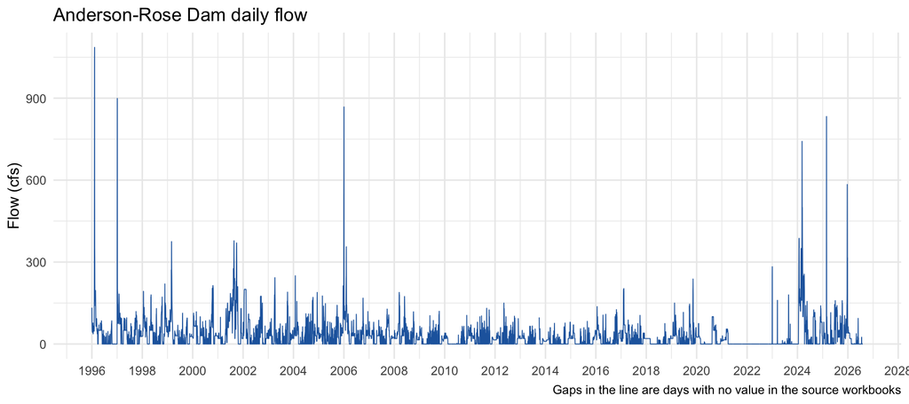

```r
ggplot(ar_daily, aes(date, value)) +
  geom_line(linewidth = 0.3, color = "#2166AC") +
  scale_x_date(date_breaks = "2 years", date_labels = "%Y") +
  labs(title = "Anderson-Rose Dam daily flow", x = NULL, y = "Flow (cfs)",
       caption = "Gaps in the line are days with no value in the source workbooks") +
  theme_minimal()
```

## Rows for `flow_data` and `flow_gage`

### `flow_data`

Same columns and types as `flow_data`. The daily value is reported as a single cfs figure per day; it is labelled `statistic = "mean"` to match the other flow sources (confirm that is what TID reports).

```r
anderson_rose_flow_data <- ar_daily |>
  filter(!is.na(value)) |>
  transmute(
    location      = ar_meta$location,
    gage_name     = ar_meta$gage_name,
    gage_id       = ar_meta$gage_id,
    variable_name = "flow",
    value         = value,
    unit          = "cfs",
    statistic     = "mean",
    date          = date
  )

glimpse(anderson_rose_flow_data)
```

```
## Rows: 11,119
## Columns: 8
## $ location      <chr> "lost river", "lost river", "lost river", "lost river", …
## $ gage_name     <chr> "anderson-rose dam", "anderson-rose dam", "anderson-rose…
## $ gage_id       <chr> "tid-anderson-rose", "tid-anderson-rose", "tid-anderson-…
## $ variable_name <chr> "flow", "flow", "flow", "flow", "flow", "flow", "flow", …
## $ value         <dbl> 133, 96, 75, 64, 54, 48, 48, 43, 54, 66, 66, 59, 48, 48,…
## $ unit          <chr> "cfs", "cfs", "cfs", "cfs", "cfs", "cfs", "cfs", "cfs", …
## $ statistic     <chr> "mean", "mean", "mean", "mean", "mean", "mean", "mean", …
## $ date          <date> 1996-01-01, 1996-01-02, 1996-01-03, 1996-01-04, 1996-01…
```

### `flow_gage`

The location is the USGS site *at* Anderson-Rose Diversion Dam at Malone, OR (`420037121334100`, “LOST RVR AT ANDERSON ROSE DVRSN DAM AT MALONE, OR”), taken from the `temperature_gage` object rather than typed in: the TID workbooks don’t give coordinates. `huc8` is assigned by point-in-polygon against `rivermile::klamath_hucs` (same as the other gage tables built outside the NHD river-mile step), and `river_mile` is `NA` as for the USBR Hydromet and OWRD gages.

```r
# USGS NWIS site 420037121334100 (the "at dam" site; 420036121333700 is the "below dam" site
# ~100 m downstream). USGS lat/long-style site numbers encode the position as DDMMSSDDDMMSS.
dam_site <- temperature_gage |> filter(gage_id == "420037121334100")
if (nrow(dam_site) != 1) stop("Expected exactly one temperature_gage row for USGS site 420037121334100, found ", nrow(dam_site))

anderson_rose_flow_gage <- tibble(
  gage_name  = ar_meta$gage_name,
  gage_id    = ar_meta$gage_id,
  agency     = ar_meta$agency,
  latitude   = dam_site$latitude,
  longitude  = dam_site$longitude,
  river_mile = NA_real_,
  location   = ar_meta$location
) |>
  st_as_sf(coords = c("longitude", "latitude"), crs = 4326, remove = FALSE) |>
  st_join(rivermile::klamath_hucs |> st_transform(4326), join = st_intersects) |>
  st_drop_geometry() |>
  mutate(huc8 = as.numeric(huc8)) |>
  select(gage_name, gage_id, agency, latitude, longitude, river_mile, huc8, location)

kable(anderson_rose_flow_gage, digits = 5)
```

| gage_name | gage_id | agency | latitude | longitude | river_mile | huc8 | location |
| --- | --- | --- | --- | --- | --- | --- | --- |
| anderson-rose dam | tid-anderson-rose | tulelake irrigation district | 42.0104 | -121.5614 | NA | 18010204 | lost river |

### Integration check

Checks that these two tables can be stacked onto the package objects as they are: same column names and types, no `gage_id` collision, and the gage’s `huc8` agrees with the one USGS has for that site. Nothing is saved.

```r
col_types <- function(df) vapply(df, function(x) class(x)[1], character(1))

tibble(
  check = c("flow_data column names and order match",
            "flow_data column types match",
            "flow_gage column names and order match",
            "flow_gage column types match",
            "gage_id not already in flow_gage",
            "gage_id not already in flow_data",
            "huc8 matches USGS record for the dam site",
            "no duplicate gage_id/date rows"),
  passes = c(
    identical(names(anderson_rose_flow_data), names(flow_data)),
    identical(col_types(anderson_rose_flow_data), col_types(flow_data)),
    identical(names(anderson_rose_flow_gage), names(flow_gage)),
    identical(col_types(anderson_rose_flow_gage), col_types(flow_gage)),
    !ar_meta$gage_id %in% flow_gage$gage_id,
    !ar_meta$gage_id %in% flow_data$gage_id,
    identical(anderson_rose_flow_gage$huc8, dam_site$huc8),
    !anyDuplicated(anderson_rose_flow_data[c("gage_id", "date")]) > 0
  )
) |> kable()
```

| check | passes |
| --- | --- |
| flow_data column names and order match | TRUE |
| flow_data column types match | TRUE |
| flow_gage column names and order match | TRUE |
| flow_gage column types match | TRUE |
| gage_id not already in flow_gage | TRUE |
| gage_id not already in flow_data | TRUE |
| huc8 matches USGS record for the dam site | TRUE |
| no duplicate gage_id/date rows | TRUE |

Stacked onto the current objects this would give 447,480 `flow_data` rows (436,361 + 11,119) and 119 `flow_gage` rows.

## Notes

- **The `location` overwrite in the `flow_data` combine step is fixed.** The combine step used to do `mutate(location = tolower(stream))` on the stacked tables, which replaced `location` with `NA` for any table that carries its name in a `location` column instead of `stream`: the USBR Hydromet and OWRD rows, about 160,000 `flow_data` rows. It now uses `coalesce(tolower(stream), location)`, and `flow-process-data.R` stops before saving if any `flow_data` location is missing or doesn’t match `flow_gage`.
- **Agency** is assumed to be Tulelake Irrigation District from the workbook names, and the workbooks’ source (who compiles and shares them) is worth confirming for attribution.
- **Statistic** `"mean"` is an assumption about how the daily cfs figure is derived.
- **The newest workbook (WY 2025-26) is only filled in through 2026-08-05.** Its later tabs are empty templates (the last one also has junk dates), which are trimmed rather than treated as gaps. When more months are entered they come through automatically.